# Anca & Rik Wedding: 30 July 2022

#### Anca & Rik - Brúðkaup : [Svara boðinu](https://forms.gle/uzLpqn1FvGNjH6sW7) ⟡ Ferðatilhögun ⟡ Gisting ⟡ Að ferðast um Transilvaníu

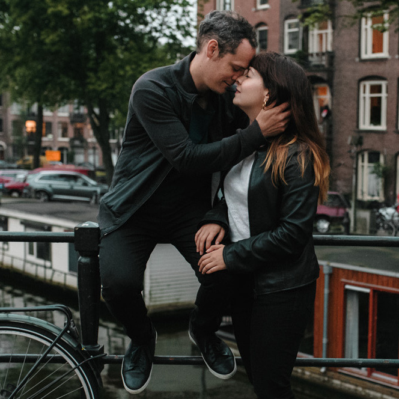

Ⓒ [TreeArcade](https://www.treearcade.com/)

## Anca & Rik

### 30 Júlí 2022 ❤️ Bistrița, Rúmeníu

[🇬🇧](https://anca-rik-wedding.github.io) 🇮🇸

Jæja, þá er loksins komið að því,þótt fyrr hefði verið segja vafalaust einhverjir. Brúðkaup í vænndum!. Við ætlum að gifta okkur 30. Júlí 2022!

Ekkert myndi gleðja okkur meira en að þú kæmir og fagnaðir með okkur.

Við erum að skipuleggja veglega hátíð á æskuslóðum Öncu [Bistrița, Rúmeníu](https://en.wikipedia.org/wiki/Bistri%C8%9Ba).

Þar fer brúðkaups athöfnin sjálf fram, sem og veisla. Flestir ættu nú að hafa gama af því. Síðan verður haldið uppí fjöll þar sem við taka tveggja daga rólegheit, afslöppun og gaman. Þangað viljum við endilega bjóða ykkur,vinum og vandamönnum. Fyrir ævintýraþyrsta verður svo boðið uppá vikulanga svaðilför um helstu kennileiti Transilvaníu. Já, líka Drakúlakastalann. Gestum er í sjálfval sett hvaða viðburði þeir vilja sækja.

Helstu dagsetningar eru því eftirfarandi:

- **Júlí 30** : kirkjubrúðkaup & veisla á [Hotel Metropolis](https://www.google.com/maps/place/Metropolis/@47.1272607,24.4966106,15z/data=!4m2!3m1!1s0x0:0x250b9cd755c23bf0?sa=X&ved=2ahUKEwjY_927vZnmAhUMUlAKHa9MDzgQ_BIwFHoECBoQCA), Bistrița
- **Júlí 31** : afterparty TBD

Kæru gestir, takið eftir. Vinsamlega skoðið ferðasíðuna en þar má sjá upplýsingar varðandi besta ferðamátann til Rúmeníu.

Við höfum tekið frá hótelherbergi fyrir alla frá og með 30 Júlí.

Ef þú er til í að leggja land undir fót og fagna með okkur, viltu þá vinsamlegast fylla inn eftirfarandi eyðublað? **[RSVP here](https://forms.gle/uzLpqn1FvGNjH6sW7)**! Og ekki hika við að senda okkur tölvupóst fyrir frekari upplýsingar! Við komum til með að senda þér/ykkur frekari upplýsingar í tölvupósti. (Anca or Rik).

**Veður:** Veðrið um miðjan Júlí er alla jafna frekar millt. 26°C að meðaltali yfir daginn og um 15°C að næturlagi. 60% raki og náttúrulega einhverjar líkur á rigningu, en við krossum puttana.

**Klæðaburður:** Fyrir Laugardag (brúðkaup og veislu) er vaninn að klæðast siðsamlega. Konur: cotail kjólar, Karlar: skyrta (með eða án bindis). Fyrir Sunnudag og mánudag í afslöppun, væri best að klæðast þægilega og afslappað. Bara þannig að þér líði sem best. Fyrir þá sem fara í viku ferðalag um Trasilvaníu, kemur listi yfir hvað er best að taka með þegar nær dregur.

**Contact:** Anca & Rik.